# Python Tutorial With Jupyter Notebook

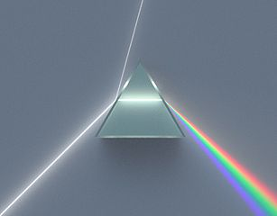

This tutorial was originally written by [Justin Johnson](https://web.eecs.umich.edu/~justincj/) for cs231n and adapted as a Jupyter notebook for cs228 by [Volodymyr Kuleshov](http://web.stanford.edu/~kuleshov/) and [Isaac Caswell](https://symsys.stanford.edu/viewing/symsysaffiliate/21335).

This current version is based on a Jupyter notebook with Python3 support by Kevin Zakka for the Spring 2020 edition of [cs231n](http://cs231n.stanford.edu/) at Stanford University.

It was adapted by [Reto Knaack](https://www.zhaw.ch/de/ueber-uns/person/knaa/) for the Autumn 2022 edition of [Höhere Mathematik 1](https://moodle.zhaw.ch/course/view.php?id=10603) at ZHAW.

## What is a Jupyter Notebook?

A Jupyter notebook is made up of a number of cells. Each cell can contain Python code. There are two main types of cells: `Code` cells and `Markdown` cells. This particular cell is a `Markdown` cell. You can execute a particular cell by double clicking on it (the highlight color will switch from blue to green) and pressing `Shift-Enter`. When you do so, if the cell is a `Code` cell, the code in the cell will run, and the output of the cell will be displayed beneath the cell, and if the cell is a `Markdown` cell, the markdown text will get rendered beneath the cell. For `Code` cells, you can also just klick on the black arrow next to it.

The cell below is a `Code` cell. Go ahead and click it, then execute it.

```python
x = 1
print(x)
```

Global variables are shared between cells. Try executing the cell below:

```python
y = 2 * x
print(y)
```

### Keyboard Shortcuts

There are a few keyboard shortcuts you should be aware of to make your notebook experience more pleasant. To escape editing of a cell, press `esc`. Escaping a `Markdown` cell won't render it, so make sure to execute it if you wish to render the markdown. Notice how the highlight color switches back to blue when you have escaped a cell.

You can navigate between cells by pressing your arrow keys. Executing a cell automatically shifts the cell cursor down 1 cell if one exists, or creates a new cell below the current one if none exist.

- To place a cell below the current one, press `b`.
- To place a cell above the current one, press `a`.
- To delete a cell, press `dd`.
- To convert a cell to `Markdown` press `m`. Note you have to be in `esc` mode.
- To convert it back to `Code` press `y`. Note you have to be in `esc` mode.

Get familiar with these keyboard shortcuts, they really help!

You can restart a notebook and clear all cells by clicking `Kernel -> Restart & Clear Output`. If you don't want to clear cell outputs, just hit `Kernel -> Restart`.

By convention, Jupyter notebooks are expected to be run from top to bottom. Failing to execute some cells or executing cells out of order can result in errors. After restarting the notebook, try running the `y = 2 * x` cell 2 cells above and observe what happens.

After you have modified a Jupyter notebook for one of the assignments by modifying or executing some of its cells, remember to save your changes! You can save with the `Command/Control + s` shortcut or by clicking `File -> Save and Checkpoint`.

This has only been a brief introduction to Jupyter notebooks, but it should be enough to get you up and running on the assignments for this course. **The full documentation about Jupyter Notebooks is given [here](https://jupyter-notebook.readthedocs.io/en/stable/notebook.html).**

> **Task 1**

> Go ahead and add two cells under this one:
> - one `Markdown` cell showing some text
> - one `Code` cell with a 'Hello World' example

*Insert Your Solution here:*

## Python Tutorial

Python is a great general-purpose programming language on its own, but with the help of a few popular libraries (numpy, scipy, matplotlib) it becomes a powerful environment for scientific computing.

This section will serve as a quick crash course both on the Python programming language and on the use of Python for scientific computing.

Some of you may have previous knowledge in Matlab, in which case we also recommend the numpy for Matlab users page (https://numpy.org/doc/stable/user/numpy-for-matlab-users.html).

But why learn Python at all? The answer is quite simple: it is open source, easy to learn, stable and has gained popularity over the last 20 years escpecially in the area of data science. In contrast to Matlab (which was previously taught in numerical math at ZHAW), Python is widely used by IT professionals and it is likely that you will encounter this language in your career again. The following video shows some pros and cons about Python (click on the Python icon):

[figure not shown]

In this tutorial, we will cover:

- Basic Python: Basic data types (Containers, Lists, Dictionaries, Sets, Tuples), Loops, Functions, Classes
- Numpy: Arrays, Array indexing, Datatypes, Array math, Broadcasting
- Matplotlib: Plotting, Subplots, Images

If you wish to have a look at the details of what is covered here, please have a look at the underlying tutorials:

- Python: https://docs.python.org/3.8/tutorial/index.html
- Numpy:https://numpy.org/doc/stable/user/quickstart.html
- Matplotlib: https://matplotlib.org/tutorials/index.html

By the way, if you do not know yet, where the name Python comes from, have a look at this video:

[figure not shown]

### A Brief Note on Python Versions

As of Janurary 1, 2020, Python has [officially dropped support](https://www.python.org/doc/sunset-python-2/) for `python2`. **We'll be using Python 3.8 or higher for this iteration of the course.**

You should by now have installed Anaconda by now (see https://www.anaconda.com/products/individual). If that is the case, the cell below should print out a major version of 3.8. or higher.

```python
!python --version
```

## Basics of Python

Python is a high-level, dynamically typed multiparadigm programming language. Python code is often said to be almost like pseudocode, since it allows you to express very powerful ideas in very few lines of code while being very readable.

### Some Examples

Here is an implementation of the classic quicksort algorithm in Python:

```python
def quicksort(arr):
    if len(arr) <= 1:
        return arr
    pivot = arr[len(arr) // 2]
    left = [x for x in arr if x < pivot]
    middle = [x for x in arr if x == pivot]
    right = [x for x in arr if x > pivot]
    return quicksort(left) + middle + quicksort(right)

print(quicksort([3,6,8,10,1,2,1]))
```

By importing libraries such as numpy and matplotlib, Python can be used to program algorithms, analyse data and visualise the results. For instance:

```python
import numpy as np
import matplotlib.pyplot as plt
plt.ion()

data = np.random.randn(2, 100)
fig, ax = plt.subplots()
ax.scatter(*data, c=data[1], s=100*np.abs(data[0]));
```

```python
import numpy as np
import matplotlib.pyplot as plt
def mandelbrot( h,w, maxit=20 ):
    """Returns an image of the Mandelbrot fractal of size (h,w)."""
    y,x = np.ogrid[ -1.4:1.4:h*1j, -2:0.8:w*1j ]
    c = x+y*1j
    z = c
    divtime = maxit + np.zeros(z.shape, dtype=int)
    for i in range(maxit):
        z = z**2 + c
        diverge = z*np.conj(z) > 2**2            # who is diverging
        div_now = diverge & (divtime==maxit)  # who is diverging now
        divtime[div_now] = i                  # note when
        z[diverge] = 2                        # avoid diverging too much
    return divtime

plt.imshow(mandelbrot(800,800))
```

### Basic data types

#### Numbers

Integers and floats work as you would expect from other languages:

```python
x = 3
print(x, type(x))
```

```python
print(x + 1)   # Addition
print(x - 1)   # Subtraction
print(x * 2)   # Multiplication
print(x ** 2)  # Exponentiation
```

```python
x += 1
print(x)
x *= 2
print(x)
```

```python
y = 2.5
print(type(y))
print(y, y + 1, y * 2, y ** 2)
```

> **Task 2**

> Can you calculate the value of $p(x) = 5\cdot x^3 - 2\cdot x^2 + 3.1\cdot x - 8$ for $x=8$?

*Insert Your Solution here:*

```python
# Your code:
```

Note that unlike many languages, Python does not have unary increment (x++) or decrement (x--) operators.

Python also has built-in types for long integers and complex numbers; you can find all of the details in the [documentation](https://docs.python.org/3.8/library/stdtypes.html#numeric-types-int-float-long-complex).

#### Booleans

Python implements all of the usual operators for Boolean logic, but uses English words 'or', 'and', 'not' rather than symbols (`||`, `&&`, etc.):

These are the Boolean operations, ordered by ascending priority:

| Operation | Result | Notes |
| --- | --- | --- |
| x or y | if x is false, then y, else x | This is a short-circuit operator, so it only evaluates the second argument if the first one is false. |
| x and y | if x is false, then x, else y | This is a short-circuit operator, so it only evaluates the second argument if the first one is true. |
| not x | if x is false, then True, else False | not has a lower priority than non-Boolean operators, so not a == b is interpreted as not (a == b), and a == not b is a syntax error. |

Booleans are defined by `True` or `False` (note the upper case)

```python
t, f = True, False
print(type(t))
```

Now we let's look at the operations. Before you execute the cell, test your knowledge by predicting the outcome of each operation:

```python
print(t or f)  # Logical OR;
print(t and f) # Logical AND;
print(not t)   # Logical NOT;
print(t != f)  # Logical XOR;
```

> **Task 3**

> Define 4 Boolean variables t1 (true), f1 (false), t2 (true), f2 (false) and test the following operations (try to estimate the > result before):
> - t1 or t2 and f1 or f2
> - (t1 or t2) and (f1 or f2)
> - f1 or f2 and t1 or t2
> - (f1 or f2) and (t1 or t2)

*Insert Your Solution here:*

```python
# Your code:
```

#### Comparisons

There are eight comparison operations in Python. They all have the same priority (which is higher than that of the Boolean operations). Comparisons can be chained arbitrarily; for example, x < y <= z is equivalent to x < y and y <= z, except that y is evaluated only once (but in both cases z is not evaluated at all when x < y is found to be false).

This table summarizes the comparison operations:

| Operation | Meaning |
| --- | --- |
| < | strictly less than |
| <= | less than or equal |
| > | strictly greater than |
| >= | greater than or equal |
| == | equal |
| != | not equal |
| is | object identity |
| is not | negated object identity |

> **Task 4**

> Define two variables *a* and *b* with given values and test if they are greater or equal than each other

*Insert your solution here*

```python
# Your code:
```

#### Strings

```python
hello = 'hello'   # String literals can use single quotes
world = "world"   # or double quotes; it does not matter
print(hello, len(hello))
```

```python
hw = hello + ' ' + world  # String concatenation
print(hw)
```

```python
hw12 = '{} {} {}'.format(hello, world, 12)  # string formatting
print(hw12)
```

String objects have a bunch of useful methods; for example:

```python
s = "hello"
print(s.capitalize())  # Capitalize a string
print(s.upper())       # Convert a string to uppercase; prints "HELLO"
print(s.rjust(7))      # Right-justify a string, padding with spaces
print(s.center(7))     # Center a string, padding with spaces
print(s.replace('l', '(ell)'))  # Replace all instances of one substring with another
print('  world '.strip())  # Strip leading and trailing whitespace
```

You can find a list of all string methods in the [documentation](https://docs.python.org/3.8/library/stdtypes.html#string-methods).

> **Task 5**

> Define the 6 follwoing string literals "A", "hitchhiker's", "guide", "to", "the", "galaxy" and concatenate them into a sentence. Print it in upper case.

> *Insert your solution here*

```python
# Your code:
```

### Containers

Python includes several built-in container types: lists, dictionaries, sets, and tuples.

#### Lists

A list is the Python equivalent of an array, but is resizeable and can contain elements of different types. Important: in Python, indexing starts at 0 (in contrast to Matlab, where it starts at 1). This means the the first element of a list x is x[0].

```python
xs = [3, 1, 2]   # Create a list
print(xs[0],xs[1], xs[2])
print(xs[-2])     # Negative indices count from the end of the list; prints "1"
```

```python
xs[2] = 'foo'    # Lists can contain elements of different types
print(xs)
```

```python
xs.append('bar') # Add a new element to the end of the list
print(xs)
```

```python
x = xs.pop()     # Remove and return the last element of the list
print(x, xs)
```

```python
nums = list(range(0,10,3))  # Create a list from 0 to 10 with a step width of 3. Works only with integers.
print(nums)
```

As usual, you can find all the gory details about lists in the [documentation](https://docs.python.org/3.8/tutorial/datastructures.html#more-on-lists).

#### Slicing

In addition to accessing list elements one at a time, Python provides concise syntax to access sublists; this is known as slicing:

```python
nums = list(range(5))    # range is a built-in function that creates a list of integers
print(nums)         # Prints "[0, 1, 2, 3, 4]"
print(nums[2:4])    # Get a slice from index 2 to 4 (exclusive); prints "[2, 3]"
print(nums[2:])     # Get a slice from index 2 to the end; prints "[2, 3, 4]"
print(nums[:2])     # Get a slice from the start to index 2 (exclusive); prints "[0, 1]"
print(nums[:])      # Get a slice of the whole list; prints ["0, 1, 2, 3, 4]"
print(nums[:-1])    # Slice indices can be negative; prints ["0, 1, 2, 3]"
nums[2:4] = [8, 9] # Assign a new sublist to a slice
print(nums)         # Prints "[0, 1, 8, 9, 4]"
```

> **Task 6**

> Create a list from 5 to 50 with step width 5. Overwrite the last 3 elements with with [100, 300, 500] and add the additional elements [700, 900]. Print the first 5 elements and the last 5 elements of the new list separately.

> *Insert your solution here*

```python
# Your code:
```

#### Loops and Control

You can loop over the elements of a list like this:

```python
animals = ['cat', 'dog', 'monkey']
for animal in animals:
    print(animal)
```

If you want access to the index of each element within the body of a loop, use the built-in `enumerate` function:

```python
animals = ['cat', 'dog', 'monkey']
for idx, animal in enumerate(animals):
    print('#{}: {}'.format(idx + 1, animal))
```

If you do need to iterate over a sequence of numbers, the built-in function range() comes in handy:

```python
for i in range(5):
    print(i)
```

> **Task 7**

> Define a list with the elements 2, 4, 6, 8 and multiply the elements using a for-loop

*Insert your solution here*

```python
# Your code:
```

A well-known statement type is the if statement. For example:

```python
x = int(input("Please enter an integer: "))

if x < 0:
    x = 0
    print('Negative changed to zero')
elif x == 0:
    print('Zero')
elif x == 1:
    print('Single')
elif x == 42:
    print("So you have found the answer to love, life and the universe (according to the hitchhiker's guide to the galaxy)")
else:
     print('Many')
```

A while loop is executet while the given Boolean expression is true. It can be refined with additional conditions within the loop, using the `break` statement to finish the loop (the opposite to `break` is `continue`):

```python
n = 5
while n > 0:
    n -= 1
    if n == 2:
        break
    print(n)
print('Loop ended.')
```

> **Task 8**

> Swap `break` with `continue` in the above while loop and see what changes.

*Insert your solution here*

```python
# Your code:
```

#### List comprehensions

When programming, frequently we want to transform one type of data into another. As a simple example, consider the following code that computes square numbers:

```python
nums = [0, 1, 2, 3, 4]
squares = []
for x in nums:
    squares.append(x ** 2)
print(squares)
```

You can make this code simpler using a list comprehension:

```python
nums = [0, 1, 2, 3, 4]
squares = [x ** 2 for x in nums]
print(squares)
```

List comprehensions can also contain conditions (`%` here is the Modulo operator):

```python
nums = [0, 1, 2, 3, 4]
even_squares = [x ** 2 for x in nums if x % 2 == 0]
print(even_squares)
```

> **Task 9**

> Calculate the third power of all uneven numbers between 0 and 30 and print them.

*Insert your solution here*

```python
#Your code:
```

#### Dictionaries

A dictionary stores (key, value) pairs, similar to a `Map` in Java or an object in Javascript. The dictionary is written with curly brackets and is unordered. Dictionaries are optimized to retrieve values when the key is known. You can use it like this:

```python
d = {'cat': 'cute', 'dog': 'furry'}  # Create a new dictionary with some data
print(d['cat'])       # Get an entry from a dictionary; prints "cute"
print('cat' in d)     # Check if a dictionary has a given key; prints "True"
```

```python
d['fish'] = 'wet'    # Set an entry in a dictionary
print(d)
print(d['fish'])      # Prints "wet"
```

```python
print(d['monkey'])  # KeyError: 'monkey' not a key of d
```

```python
print(d.get('monkey', 'N/A'))  # Get an element with a default; prints "N/A"
print(d.get('fish', 'N/A'))    # Get an element with a default; prints "wet"
```

```python
del d['fish']        # Remove an element from a dictionary
print(d.get('fish', 'N/A')) # "fish" is no longer a key; prints "N/A"
```

You can find all you need to know about dictionaries in the [documentation](https://docs.python.org/2/library/stdtypes.html#dict).

It is easy to iterate over the keys in a dictionary:

```python
d = {'person': 2, 'cat': 4, 'spider': 8}
for animal, legs in d.items():
    print('A {} has {} legs'.format(animal, legs))
```

Dictionary comprehensions: These are similar to list comprehensions, but allow you to easily construct dictionaries. For example:

```python
nums = [0, 1, 2, 3, 4]
even_num_to_square = {x: x ** 2 for x in nums if x % 2 == 0}
print(even_num_to_square)
```

#### Sets

A set is an unordered collection of distinct elements. As a simple example, consider the following:

```python
animals = {'cat', 'dog'}
print('cat' in animals)   # Check if an element is in a set; prints "True"
print('fish' in animals)  # prints "False"
```

```python
animals.add('fish')      # Add an element to a set
print('fish' in animals)
print(len(animals))       # Number of elements in a set;
```

```python
animals.add('cat')       # Adding an element that is already in the set does nothing
print(len(animals))
animals.remove('cat')    # Remove an element from a set
print(len(animals))
```

*Loops*: Iterating over a set has the same syntax as iterating over a list; however since sets are unordered, you cannot make assumptions about the order in which you visit the elements of the set:

```python
animals = {'cat', 'dog', 'fish'}
for idx, animal in enumerate(animals):
    print('#{}: {}'.format(idx + 1, animal))
```

Set comprehensions: Like lists and dictionaries, we can easily construct sets using set comprehensions:

```python
from math import sqrt
print({int(sqrt(x)) for x in range(30)})
```

#### Tuples

A tuple is an (immutable) ordered list of values. Immutable means that it cannot be changed any more after its creation. A tuple is in many ways similar to a list; one of the most important differences is that tuples can be used as keys in dictionaries and as elements of sets, while lists cannot. Here is a trivial example:

```python
d = {(x, x + 1): x for x in range(10)}  # Create a dictionary with tuple keys
t = (5, 6)       # Create a tuple
print(type(t))
print(d[t])
print(d[(1, 2)])
```

```python
t[0] = 1
```

### Functions

Python functions are defined using the `def` keyword. For example:

```python
def sign(x):
    if x > 0:
        return 'positive'
    elif x < 0:
        return 'negative'
    else:
        return 'zero'

for x in [-1, 0, 1]:
    print(sign(x))
```

We will often define functions to take optional keyword arguments, like this:

> **Task 10**

> Define a function fib(n) that prints the Fibonacci numbers between 0 and n (i.e. 0 1 1 2 3 5 8 13 etc.)

*Insert your solution here*

```python
#Your code:
```

Another example:

```python
def hello(name, loud=False):
    if loud:
        print('HELLO, {}'.format(name.upper()))
    else:
        print('Hello, {}!'.format(name))

hello('Bob')
hello('Fred', loud=True)
```

The `return` statement returns with a value from a function:

```python
def fib2(n):  # return Fibonacci series up to n
    """Return a list containing the Fibonacci series up to n."""
    result = []
    a, b = 0, 1
    while a < n:
        result.append(a)    # see below
        a, b = b, a+b
    return result

f100 = fib2(100)    # call it
f100                # write the result
```

> **Task 11**

> Define a function square_root(x) that calculates the square root of a real number x by applying the following steps:
> - start with a guess, a real number $g$
> - if $g\cdot g$ is close enough to x, then stop
> - else use the average of $g$ and $x/g$ as new guess, i.e. set $g=(g+x/g)/2$
> - repeat

> Calculate the square root of a few real numbers.

*Insert your solution here*

```python
#Your code:
```

### Classes

The syntax for defining classes in Python is straightforward:

```python
class Greeter:

    # Constructor
    def __init__(self, name):
        self.name = name  # Create an instance variable

    # Instance method
    def greet(self, loud=False):
        if loud:
          print('HELLO, {}'.format(self.name.upper()))
        else:
          print('Hello, {}!'.format(self.name))

g = Greeter('Fred')  # Construct an instance of the Greeter class
g.greet()            # Call an instance method; prints "Hello, Fred"
g.greet(loud=True)   # Call an instance method; prints "HELLO, FRED!"
```

## Numpy

NumPy is the fundamental package for scientific computing in Python. It is a Python library that provides a multidi-mensional array object, various derived objects (such as masked arrays and matrices), and an assortment of routines forfast operations on arrays, including mathematical, logical, shape manipulation, sorting, selecting, I/O, discrete Fouriertransforms, basic linear algebra, basic statistical operations, random simulation and much more. If you are already familiar with MATLAB, you might find this [tutorial](https://numpy.org/doc/stable/user/numpy-for-matlab-users.html) useful to get started with Numpy.

At the core of the NumPy package, is the `ndarray` object. This encapsulates n-dimensional arrays of homogeneous datatypes, with many operations being performed in compiled code for performance. There are several important differences between NumPy arrays and the standard Python sequences:

- NumPy arrays have a fixed size at creation, unlike Python lists (which can grow dynamically). Changing the size of an ndarray will create a new array and delete the original.
- The elements in a NumPy array are all required to be of the same data type, and thus will be the same size inmemory. The exception: one can have arrays of (Python, including NumPy) objects, thereby allowing for arrays of different sized elements.
- NumPy arrays facilitate advanced mathematical and other types of operations on large numbers of data. Typically,such operations are executed more efficiently and with less code than is possible using Python’s built-in sequences.
- A growing plethora of scientific and mathematical Python-based packages are using NumPy arrays; though these typically support Python-sequence input, they convert such input to NumPy arrays prior to processing, and they often output NumPy arrays. In other words, in order to efficiently use much (perhaps even most) of today’s scientific/mathematical Python-based software, just knowing how to use Python’s built-in sequence types is insufficient ... one also needs to know how to use NumPy arrays (excerpt from the [NumPy User Guide](https://numpy.org/doc/stable/numpy-user.pdf)).

To use Numpy, we first need to import the `numpy` package:

```python
import numpy as np
```

### Arrays

A numpy array is a grid of values, all of the same type, and is indexed by a tuple of nonnegative integers. The number of dimensions is the rank of the array; the shape of an array is a tuple of integers giving the size of the array along each dimension.

What is the difference between a Python list and a NumPy array? While a Python list can contain different data types within a single list, all of the elements in a NumPy array should be homogenous. The mathematical operations that are meant to be performed on arrays would be extremely inefficient if the arrays weren’t homogenous.

We can initialize numpy arrays from nested Python lists, and access elements using square brackets. Regarding the notation: vectors (rank 1 arrays) are in lower case, matrices (rank 2 arrays) in upper case:

```python
a = np.array([1, 2, 3])  # Create a rank 1 array, or in other words, a vector
print(type(a), a.shape, a[0], a[1], a[2])
a[0] = 5                 # Change an element of the array
print(a)
```

Note that in the above example, a=np.array([1, 2, 3]) is neither a row nor column vector, i.e. its second dimension is undefined. If you want a to be a row vector or column vector, you have to use additional brackets [ ]:

```python
a_row = np.array([[1, 2, 3]])     # row vector (1 row, 3 columns)
print(a_row)
print(a_row.shape)
a_col = np.array([[1],[2],[3]])   # column vector (3 rows, 1 column)
print(a_col)
print(a_col.shape)
```

```python
B = np.array([[1,2,3],[4,5,6]])   # Create a rank 2 array, or in other words a 2x3 matrix (2 rows, 3 columns)
print(B)
```

```python
print(B.shape)
print(B[0, 0], B[0, 1], B[1, 0])
```

Numpy also provides many functions to create arrays:

```python
A = np.zeros((2,2))  # Create an array of all zeros
print(A)
```

```python
B = np.ones((1,2))   # Create an array of all ones
print(B)
```

```python
C = np.full((2,2), 7) # Create a constant array
print(C)
```

```python
D = np.eye(2)        # Create a 2x2 identity matrix
print(D)
```

```python
E = np.random.random((4,4)) # Create an array filled with random values between 0 and 1
print(E)
```

```python
f = np.arange(10,20,3)  # Create an array from start=10 to stop=20 (exclusive) with step=3
print(f)
```

```python
G = np.arange(30).reshape(3,10)  # Create rank 2 array from with 3 rows and 10 columns (i.e. a 3x10 matrix)
print(G)
```

> **Task 12**

> Create a 3x3 matrix filled with the square of random numbers and add the 3x3 identity matrix

*Insert your solution here*

```python
#Your code:
```

### Datatypes

Every numpy array is a grid of elements of the same type. Numpy provides a large set of numeric datatypes that you can use to construct arrays. Numpy tries to guess a datatype when you create an array, but functions that construct arrays usually also include an optional argument to explicitly specify the datatype. If you want to find out which data type the array consists of, use `dtype`, with which you can also to define the data type when the array is created. Here is an example:

```python
x = np.array([1, 2])  # Let numpy choose the datatype
y = np.array([1.0, 2.0])  # Let numpy choose the datatype
z = np.array([1, 2], dtype=np.int64)  # Force a particular datatype

print(x.dtype, y.dtype, z.dtype)
```

You can read all about numpy datatypes in the [documentation](http://docs.scipy.org/doc/numpy/reference/arrays.dtypes.html).

> **Task 13**

> Create a 3x8 matrix A using `arange` and `reshape` and datatytpe 'int32'. Then change it to 'float64'.

*Insert your solution here*

```python
#Your code:
```

### Array indexing and slicing

Numpy offers several ways to index and slice arrays. Array indexing refers to any use of the square brackets ([]) to index array values, e.g. x[0]. Array slicing is an operation that extracts a subset of elements from an array and packages them as another array, possibly in a different dimension from the original [link](https://en.wikipedia.org/wiki/Array_slicing). There are many options to indexing and slicing in NumPy, which gives indexing great power, but with power comes some complexity and the potential for confusion. Also remember that Python indexing starts at 0 (not 1).

The basic slice syntax is i:j:k where i is the starting index, j is the stopping index, and k is the step ($k\neq0$).

**Careful: NumPy slicing creates a view of the original data instead of a copy, so a slice of an array is a view into the same data and modifying it will modify the original array. See the example below.**

```python
x = np.arange(10,30,3)
print(x)
print(x[0])
print(x[1:7:2])   # show the elements from index 1 to index 7 (exclusive) in steps of 2
print('--------')
b = x[0:3] # create a view (not a copy!) of the first 3 elements of x
print(b)
b[0] = 1000 # overwrite the first element of b and thus also of x
print('b[0]= ',b[0])
print('x[0]= ',x[0])
```

In case you want to create a copy, use the command `np.copy()`:

```python
x = np.arange(10,30,3)
b = np.copy(x[0:3]) # create a copy of the first 3 elements of x
print(b)
b[0] = 1000 # overwrite the first element of b but not of x
print('b[0]= ',b[0])
print('x[0]= ',x[0])
```

Negative i and j are interpreted as n + i and n + j where n is the number of elements in the corresponding dimension. Negative k makes stepping go towards smaller indices.

```python
print(x)
print(x[-2:])      # show the elements from the second last one to the end
print(x[-2:1:-1])  # show the elements from the third last one to the second (exclusive) in decreasing order
```

Since arrays may be multidimensional, you must specify a slice for each dimension of the array:

```python
# Create the following rank 2 array with shape (3, 4), i.e. a 3x4 matrix
# [[ 1  2  3  4]
#  [ 5  6  7  8]
#  [ 9 10 11 12]]
A = np.array([[1,2,3,4], [5,6,7,8], [9,10,11,12]])
print(A)

# Use slicing to pull out the subarray consisting of the first 2 rows
# and columns 1 and 2; b is the following array of shape (2, 2):
# [[2 3]
#  [6 7]]
B = A[:2, 1:3]
print(B)
```

A slice of an array is a view into the same data, so modifying it will modify the original array (unlike Matlab).

```python
print(A[0, 1])
B[0, 0] = 77    # B[0, 0] is the same piece of data as A[0, 1]
print(A[0, 1])
```

If you want to manipulate a part of data without changing the original, copy the array first.

```python
C = np.copy(B)
print(A[0, 1])
C[0, 0] = 10    # C[0, 0] is the same piece of data as A[0, 1]
print(A[0, 1])
```

You can also mix integer indexing with slice indexing. However, doing so will yield an array of lower rank than the original array. Note that this is quite different from the way that MATLAB handles array slicing:

```python
# Create the following rank 2 array with shape (3, 4)
A = np.array([[1,2,3,4], [5,6,7,8], [9,10,11,12]])
print(A)
```

Two ways of accessing the data in the middle row of the array. Mixing integer indexing with slices yields an array of lower rank, while using only slices yields an array of the same rank as the original array:

```python
row_r1 = A[1, :]    # Rank 1 view of the second row of A
row_r2 = A[1:2, :]  # Rank 2 view of the second row of A
row_r3 = A[[1], :]  # Rank 2 view of the second row of A
print(row_r1, row_r1.shape)
print(row_r2, row_r2.shape)
print(row_r3, row_r3.shape)
```

```python
# We can make the same distinction when accessing columns of an array:
col_r1 = A[:, 1]
col_r2 = A[:, 1:2]
print(col_r1, col_r1.shape)
print()
print(col_r2, col_r2.shape)
```

Integer array indexing: When you index into numpy arrays using slicing, the resulting array view will always be a subarray of the original array. In contrast, integer array indexing allows you to construct arbitrary arrays using the data from another array. Here is an example:

```python
A = np.array([[1,2], [3, 4], [5, 6]])
print(A)
print('')

# An example of integer array indexing.
# The returned array will have shape (3,)
print(A[[0, 1, 2], [0, 1, 0]])

# The above example of integer array indexing is equivalent to this:
print(np.array([A[0, 0], A[1, 1], A[2, 0]]))
```

```python
# When using integer array indexing, you can reuse the same
# element from the source array:
print(A[[0, 0], [1, 1]])

# Equivalent to the previous integer array indexing example
print(np.array([A[0, 1], A[0, 1]]))
```

One useful trick with integer array indexing is selecting or mutating one element from each row of a matrix:

```python
# Create a new array from which we will select elements
A = np.array([[1,2,3], [4,5,6], [7,8,9], [10, 11, 12]])
print(A)
```

```python
# Create an array of indices
b = np.array([0, 2, 0, 1])

# Select one element from each row of a using the indices in b
print(A[np.arange(4), b])  # Prints "[ 1  6  7 11]"
# Equivalent
print(np.array([A[0, 0], A[1, 2], A[2, 0], A[3, 1]]))
```

```python
# Mutate one element from each row of a using the indices in b
A[np.arange(4), b] += 10
print(A)
```

Boolean array indexing: Boolean array indexing lets you pick out arbitrary elements of an array. Frequently this type of indexing is used to select the elements of an array that satisfy some condition. Here is an example:

```python
A = np.array([[1,2], [3, 4], [5, 6]])

bool_idx = (A > 2)  # Find the elements of a that are bigger than 2;
                    # this returns a numpy array of Booleans of the same
                    # shape as a, where each slot of bool_idx tells
                    # whether that element of a is > 2.

print(A)
print('')
print(bool_idx)
```

```python
# We use boolean array indexing to construct a rank 1 array
# consisting of the elements of a corresponding to the True values
# of bool_idx
print(A[bool_idx])

# We can do all of the above in a single concise statement:
print(A[A > 2])
```

For brevity we have left out a lot of details about numpy array indexing; if you want to know more you should read the [documentation](https://numpy.org/doc/stable/user/basics.indexing.html#basics-indexing).

> **Task 14**

> Create a 4x7 matrix A of datatytpe 'float64' with `np.arange` and `np.reshape`. Then
> - create a matrix B as slice of A(2:4,3:7)
> - change all values in B to 100 and observe how the original vaules in A also change to 100
> - create a copy C of B and ovbserve that manipultions in C do not change A any more

*Insert your solution here*

```python
#Your code:
```

### Linear Algebra / array math

#### Elementwise operations

Basic mathematical functions operate elementwise on arrays, and are available both as operator overloads and as functions in the numpy module:

```python
A = np.array([[1,2],[3,4]], dtype=np.float64)
B = np.array([[5,6],[7,8]], dtype=np.float64)

# Elementwise sum; both produce the array
print(A)
print(B)
print('')
print(A + B)
print(np.add(A, B))
```

```python
# Elementwise difference; both produce the array
print(A - B)
print(np.subtract(A, B))
```

```python
# Elementwise product; both produce the array. This is not matrix multiplication!
print(A * B)
print(np.multiply(A, B))
```

```python
# Elementwise division; both produce the array
# [[ 0.2         0.33333333]
#  [ 0.42857143  0.5       ]]
print(A / B)
print(np.divide(A, B))
```

```python
# Elementwise square root; produces the array
# [[ 1.          1.41421356]
#  [ 1.73205081  2.        ]]
print(np.sqrt(A))
```

Note that unlike MATLAB, `*` is elementwise multiplication, not matrix multiplication.

#### Matrix operations

We instead use the `dot()` function to compute inner products of vectors, to multiply a vector by a matrix, and to multiply matrices.

##### Inner product of vectors

> **Task 15**

> Can you write down the dot product (also inner product, in German 'Skalarprodukt') of two vectors

> $$ \overrightarrow{x}\cdot\overrightarrow{y}=(x_{1},\,x_{2},\,...,\,x_{n})\cdot\left(\begin{array}{c} y_{1}\\ y_{2}\\ \vdots\\ y_{n} \end{array}\right)=? $$

*Insert your solution here*

...

`dot` is available both as a function in the numpy module and as an instance method of array objects. Let us have a look at the following example:

```python
v = np.array([9,10])
w = np.array([11, 12])

# Inner product of vectors; both produce 219
print(v.dot(w))
print(np.dot(v, w))
```

You can also use the `@` operator which is equivalent to numpy's `dot` operator.

```python
print(v @ w)
```

##### Matrix product

Now consider the product of two matrices $C$ and $D$

$$ C\cdot D=\left(\begin{array}{cccc} c_{11} & c_{12} & \cdots & c_{1p}\\ c_{21} & c_{22} & \cdots & c_{2p}\\ \vdots & \vdots & \ddots & \vdots\\ c_{m1} & c_{m2} & \cdots & c_{mp} \end{array}\right)\cdot\left(\begin{array}{cccc} d_{11} & d_{12} & \cdots & d_{1n}\\ d_{21} & d_{22} & \cdots & d_{2n}\\ \vdots & \vdots & \ddots & \vdots\\ d_{p1} & d_{p2} & \cdots & d_{pn} \end{array}\right)=\left(\begin{array}{cccc} e_{11} & e_{12} & \cdots & e_{1n}\\ e_{21} & e_{22} & \cdots & e_{2n}\\ \vdots & \vdots & \ddots & \vdots\\ e_{p1} & e_{p2} & \cdots & e_{pn} \end{array}\right) $$

where we calculate the dot product of each row of $C$ with each column of $D$

$$ e_{ij}=(c_{i1}\:c_{i2}\:\cdots\:c_{ip})\cdot\left(\begin{array}{c} d_{1j}\\ d_{2j}\\ \vdots\\ d_{pj} \end{array}\right)=c_{i1}d_{1j}+c_{i2}d_{2j}+\ldots+c_{ip}d_{pj}=\sum_{k=1}^{p}c_{ik}d_{kj} $$

> Careful: The product of two matrices C and D only exists if the number of columns of the matrix C is equal to the number of rows of the matrix D. The product of two matrices is not commutative, i.e. the products $$C\cdot D$$ and $$D\cdot C$$ are generally not equal.

As an example we have

$$ C=\left(\begin{array}{ccc} 1 & 2 & 2\\ 3 & 5 & 7 \end{array}\right),\ D=\left(\begin{array}{cc} 3 & 5\\ 5 & 7\\ 9 & 8 \end{array}\right) $$$$ C\cdot D=\left(\begin{array}{cc} 1\cdot3+2\cdot5+2\cdot9 & \:1\cdot5+2\cdot7+2\cdot8\\ 3\cdot3+5\cdot5+7\cdot9 & \:3\cdot5+5\cdot7+7\cdot8 \end{array}\right)=\left(\begin{array}{cc} 31 & 35\\ 97 & 106 \end{array}\right) $$$$ D\cdot C=\left(\begin{array}{ccc} 3\cdot1+5\cdot3 & \,3\cdot2+5\cdot5 & \,3\cdot2+5\cdot7\\ 5\cdot1+7\cdot3 & \,5\cdot2+7\cdot5 & \,5\cdot2+7\cdot7\\ 9\cdot1+8\cdot3 & \,9\cdot2+8\cdot5 & \,9\cdot2+8\cdot7 \end{array}\right)=\left(\begin{array}{ccc} 18 & 31 & 41\\ 26 & 45 & 59\\ 33 & 58 & 74 \end{array}\right) $$

```python
# Matrix / matrix product

C = np.array([[1,2,2],[3,5,7]])
D = np.array([[3,5],[5,7],[9,8]])

print(C.dot(D))
print(np.dot(C, D))
print(C @ D)
print('')

print(D.dot(C))
print(np.dot(D, C))
print(D @ C)
```

##### Matrix vector product

Generally we have

$$ F\cdot\vec{z}=\left(\begin{array}{cccc} f_{11} & f_{12} & \cdots & f_{1n}\\ f_{21} & f_{22} & \cdots & f_{2n}\\ \vdots & \vdots & \ddots & \vdots\\ f_{m1} & f_{m2} & \cdots & f_{mn} \end{array}\right)\cdot\left(\begin{array}{c} z_{1}\\ z_{2}\\ \vdots\\ z_{n} \end{array}\right)=\left(\begin{array}{c} f_{11}z_{1}+f_{12}z_{2}+\ldots+f_{1n}z_{n}\\ f_{21}z_{1}+f_{22}z_{2}+\ldots+f_{2n}z_{n}\\ \vdots\\ f_{m1}z_{1}+f_{m2}z_{2}+\ldots+f_{mn}z_{n} \end{array}\right) $$

Look at the concrete example

```python
# Matrix / vector product; all three options produce the same rank 1 array
F = np.array([[-1,8,2],[5,3,1],[7,4,3]])
z = np.array([3,-2,6])

print(F.dot(z))
print(np.dot(F, z))
print(F @ z)
F.dot(z).shape
```

Note that the in the above example, the resulting vector $F\cdot\vec{z}$ is neither a row vector nor a column vector because $\vec{z}$ is defined as rank 1 array. The following code produces a column vector:

```python
F = np.array([[-1,8,2],[5,3,1],[7,4,3]])
z = np.array([3,-2,6]).reshape(3,1)

print(F.dot(z))
F.dot(z).shape
```

Could $\vec{z}$ also be defined as a row vector? Obviously not, since the dimensions of $F$ (3x3) and $\vec{z}$ (1x3) would disagree:

```python
F = np.array([[-1,8,2],[5,3,1],[7,4,3]])
z = np.array([3,-2,6]).reshape(1,3)

print(F.dot(z))
F.dot(z).shape
```

##### Computations on array

Numpy provides many useful functions for performing computations on arrays; one of the most useful is `sum`:

```python
G = np.array([[1,2],[3,4]])

print(np.sum(G))  # Compute sum of all elements; prints "10"
print(np.sum(G, axis=0))  # Compute sum of each column; prints "[4 6]"
print(np.sum(G, axis=1))  # Compute sum of each row; prints "[3 7]"
```

You can find the full list of mathematical functions provided by numpy in the [documentation](http://docs.scipy.org/doc/numpy/reference/routines.math.html).

Apart from computing mathematical functions using arrays, we frequently need to reshape or otherwise manipulate data in arrays. The simplest example of this type of operation is transposing a matrix; to transpose a matrix, simply use the T attribute of an array object:

```python
print(G)
print("transpose\n", G.T)
```

```python
v = np.array([[1,2,3]])
print(v )
print("transpose\n", v.T)
```

> **Task 16**

> Given are the matrices and vectors

> $$ A=\left(\begin{array}{crr} 4 & 1 & -2\\ 2 & 0 & 1\\ 2 & -1 & 1 \end{array}\right),\;B=\left(\begin{array}{cr} 2 & 3\\ 1 & 12\\ 0 & -2 \end{array}\right),\;x=\left(\begin{array}{c} 1\\ 7\\ 3 \end{array}\right),\;y=\left(\begin{array}{r} -2\\ 1\\ 5 \end{array}\right) $$

> Calculate, if defined, the following products:

> $$ AB, BA, Ax, AA, BB, BB^{T}, y^{T}x, yx, xy^{T}, x^{T}y, B^{T}y, y^{T}B, $$

*Insert your solution here*

```python
# Your code
```

### Broadcasting

Broadcasting is a powerful mechanism that allows numpy to work with arrays of different shapes when performing arithmetic operations. Frequently we have a smaller array and a larger array, and we want to use the smaller array multiple times to perform some operation on the larger array.

For example, suppose that we want to add a constant vector to each row of a matrix. We could do it like this:

```python
# We will add the vector v to each row of the matrix x,
# storing the result in the matrix y
A = np.array([[1,2,3], [4,5,6], [7,8,9], [10, 11, 12]])
b = np.array([1, 0, 1])
B = np.empty_like(A)   # Create an empty matrix with the same shape as x

# Add the vector v to each row of the matrix A with an explicit loop
for i in range(4):
    B[i, :] = A[i, :] + v

print(B)
```

This works; however when the matrix $A$ is very large, computing an explicit loop in Python could be slow. Note that adding the vector $v$ to each row of the matrix $A$ is equivalent to forming a matrix $V$ by stacking multiple copies of $v$ vertically, then performing elementwise summation of $A$ and $V$. We could implement this approach like this:

```python
V = np.tile(v, (4, 1))  # Stack 4 copies of v on top of each other
print(V)                # Prints "[[1 0 1]
                         #          [1 0 1]
                         #          [1 0 1]
                         #          [1 0 1]]"
```

```python
Y = A + V  # Add A and V elementwise
print(Y)
```

Numpy broadcasting allows us to perform this computation without actually creating multiple copies of v. Consider this version, using broadcasting:

```python
# We will add the vector v to each row of the matrix x,
# storing the result in the matrix y
X = np.array([[1,2,3], [4,5,6], [7,8,9], [10, 11, 12]])
v = np.array([1, 0, 1])
Y = X + v  # Add v to each row of x using broadcasting
print(Y)
```

The line $Y = X + v$ works even though $X$ has shape $(4, 3)$ and $v$ has shape $(3,)$ due to broadcasting; this line works as if $v$ actually had shape $(4, 3)$, where each row was a copy of $v$, and the sum was performed elementwise.

Broadcasting two arrays together follows these rules:

1. If the arrays do not have the same rank, prepend the shape of the lower rank array with 1s until both shapes have the same length.
2. The two arrays are said to be compatible in a dimension if they have the same size in the dimension, or if one of the arrays has size 1 in that dimension.
3. The arrays can be broadcast together if they are compatible in all dimensions.
4. After broadcasting, each array behaves as if it had shape equal to the elementwise maximum of shapes of the two input arrays.
5. In any dimension where one array had size 1 and the other array had size greater than 1, the first array behaves as if it were copied along that dimension

If this explanation does not make sense, try reading the explanation from the [documentation](http://docs.scipy.org/doc/numpy/user/basics.broadcasting.html) or this [explanation](http://wiki.scipy.org/EricsBroadcastingDoc).

Functions that support broadcasting are known as universal functions. You can find the list of all universal functions in the [documentation](http://docs.scipy.org/doc/numpy/reference/ufuncs.html#available-ufuncs).

Here are some applications of broadcasting:

```python
# Compute outer product of vectors
v = np.array([1,2,3])  # v has shape (3,)
w = np.array([4,5])    # w has shape (2,)
# To compute an outer product, we first reshape v to be a column
# vector of shape (3, 1); we can then broadcast it against w to yield
# an output of shape (3, 2), which is the outer product of v and w:

print(np.reshape(v, (3, 1)) * w)
```

```python
# Add a vector to each row of a matrix
x = np.array([[1,2,3], [4,5,6]])
# x has shape (2, 3) and v has shape (3,) so they broadcast to (2, 3),
# giving the following matrix:

print(x + v)
```

```python
# Add a vector to each column of a matrix
# x has shape (2, 3) and w has shape (2,).
# If we transpose x then it has shape (3, 2) and can be broadcast
# against w to yield a result of shape (3, 2); transposing this result
# yields the final result of shape (2, 3) which is the matrix x with
# the vector w added to each column. Gives the following matrix:

print((x.T + w).T)
```

```python
# Another solution is to reshape w to be a row vector of shape (2, 1);
# we can then broadcast it directly against x to produce the same
# output.
print(x + np.reshape(w, (2, 1)))
```

```python
# Multiply a matrix by a constant:
# x has shape (2, 3). Numpy treats scalars as arrays of shape ();
# these can be broadcast together to shape (2, 3), producing the
# following array:
print(x * 2)
```

Broadcasting typically makes your code more concise and faster, so you should strive to use it where possible.

This brief overview has touched on many of the important things that you need to know about numpy, but is far from complete. Check out the [numpy reference](http://docs.scipy.org/doc/numpy/reference/) to find out much more about numpy.

## Matplotlib

Matplotlib is a plotting library. In this section give a brief introduction to the `matplotlib.pyplot` module, which provides a plotting system similar to that of MATLAB.

```python
import matplotlib.pyplot as plt
```

By running this special iPython command, we will be displaying plots inline:

```python
%matplotlib inline
```

### Plotting

The most important function in `matplotlib` is plot, which allows you to plot 2D data. Here is a simple example:

```python
# Compute the x and y coordinates for points on a sine curve
x = np.arange(0, 3 * np.pi, 0.1)
y = np.sin(x)

# Plot the points using matplotlib
plt.plot(x, y)
```

With just a little bit of extra work we can easily plot multiple lines at once, and add a title, legend, axis labels, and a grid:

```python
y_sin = np.sin(x)
y_cos = np.cos(x)

# Plot the points using matplotlib
plt.plot(x, y_sin)
plt.plot(x, y_cos)
plt.xlabel('x axis label')
plt.ylabel('y axis label')
plt.title('Sine and Cosine')
plt.legend(['Sine', 'Cosine'])
plt.grid()
```

> **Task 17**

> Plot the following exponential functions in the same plot for $x\in[-2,2]$. Add axis labels, a title, a legend, and a grid:

> $$f_1(x) = e^x$$$$f_2(x) = e^{-x}$$

> Use np.exp()

*Insert your solution here*

```python
# Your code
```

### Subplots

You can plot different things in the same figure using the subplot function. Here is an example:

```python
# Compute the x and y coordinates for points on sine and cosine curves
x = np.arange(0, 3 * np.pi, 0.1)
y_sin = np.sin(x)
y_cos = np.cos(x)

# Set up a subplot grid that has height 2 and width 1,
# and set the first such subplot as active.
plt.subplot(2, 1, 1)

# Make the first plot
plt.plot(x, y_sin)
plt.title('Sine')

# Set the second subplot as active, and make the second plot.
plt.subplot(2, 1, 2)
plt.plot(x, y_cos)
plt.title('Cosine')

# Show the figure.
plt.show()
```

You can read much more about the `subplot` function in the [documentation](http://matplotlib.org/api/pyplot_api.html#matplotlib.pyplot.subplot).

We can plot histograms:

```python
rg = np.random.default_rng(1)
# Build a vector of 10000 normal deviates with variance 0.5^2 and mean 2
mu, sigma = 2, 0.5
v = rg.normal(mu,sigma,10000)
# Plot a normalized histogram with 50 bins
plt.hist(v, bins=50, density=1)       # matplotlib version (plot)
# Compute the histogram with numpy and then plot it
(n, bins) = np.histogram(v, bins=50, density=True)  # NumPy version (no plot)
plt.plot(.5*(bins[1:]+bins[:-1]), n)
```

And also three dimensional figures:

```python
from mpl_toolkits.mplot3d import Axes3D
fig = plt.figure()
ax = Axes3D(fig)
X = np.arange(-5, 5, 0.15)
Y = np.arange(-5, 5, 0.15)
X, Y = np.meshgrid(X, Y)
R = np.sqrt(X**2 + Y**2)
Z = np.sin(R)

ax.plot_surface(X, Y, Z, rstride=1, cstride=1, cmap='viridis')
```

> **Task 18**

> Consider the polynomial

> $$p(x) = 2x^5 - 3x^4 + 7x^3 +2x^2 - x + 5$$

> .

> Create a plot that shows this polnomial for $x\in[0,10]$

*Insert your solution here*

```python
# Your code
```